# Missing data

Social and Cultural Analytics (7AAVBCS5)

Dr Mark J. Hill · mark.j.hill@kcl.ac.uk

2026-10-19

## Rescehduled lecture

We’ve rescheduled the missed lecture for **November 11, 9:00-11:00 in STR 242.**

There will be additional workshop hours over revision week, and I will extend my office hours for those who cannot make those.

## Lecture Plan

- **Part I: Missing data**
  - What counts as missing
  - `NaN`, `None`, and `.isna()`
  - Why pandas can be quiet about gaps
- **Part II: Missingness in London cultural data**
  - Counts and percentages
  - Website, postcode, and address fields
  - Missingness as evidence
- **Part III: Strategies**
  - Delete, fill, or keep
  - Missingness indicators
  - Preserving the original data
- **Part IV: Joining context**
  - How borough context gets attached
  - Checking whether missingness is patterned
- **Part V: Live coding**

**Key Learning Outcomes**

By the end of this week you will be able to:

- identify missing values in pandas
- quantify missingness with counts and percentages
- explain why missingness may be meaningful
- choose a defensible missing-data strategy
- create missingness indicators
- join venue records to borough context
- interpret missingness with denominators and caution

# Review

**What we’ve learned so far**

- Python as a calculator
- Data types (`int`, `float`, `str`, `bool`)
- How to assign variables
- Manipulating/operating on variables
- Notebook basics
- Lists, indexing and slicing
- Arrays (numpy) and array-wise operations
- Basic descriptive stats
  - min, max, sum, mean, median, standard deviation
- Dictionaries
- f-strings
- Comparisons and `if`/`elif`/`else`

**What we learned last week**

- Data frames store rows and columns
- One row should describe one thing
- `pd.read_csv()` loads CSV files
- `.info()`, `.head()`, `.shape`, `.columns`, and `.describe()` inspect structure
- Square brackets select columns
- `.loc[]` selects by label
- `.iloc[]` selects by position
- Masks filter rows
- `to_csv(index=False)` saves data without writing row labels

**This week:** what happens when a table has gaps

# Part I: Missing Data

## Missing data

**What is missing data?**

- a value that should logically exist, but does not
- a blank in a public record
- a field skipped by a survey respondent
- a place that cannot be joined to another geography because a postcode is absent
- an unknown value created by earlier data collection choices

**Why it matters**

- summaries may use fewer rows than you think
- comparisons may exclude particular places or groups
- missingness can reveal how the dataset was made

## A historical gap: London, 1666

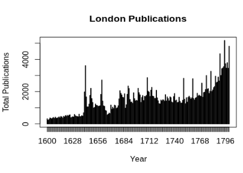

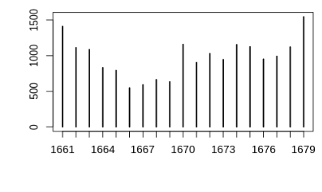

**ESTC publication records show a marked fall around 1666.**

The Great Fire disrupted London’s publishing infrastructure. The gap is evidence of a historical event, not a value to fill in.

Source: English Short Title Catalogue (ESTC)

## Why values go missing

| Cause | Example | Question to ask |
| --- | --- | --- |
| Recording error | a field was left blank during data entry | Is the error scattered or concentrated? |
| Non-response | someone does not answer an income question | Who is more likely not to answer? |
| Impossible to record | a historical source no longer exists | What historical process produced the gap? |
| By design | a field does not apply to some rows | Is this really missing, or not applicable? |

## When a gap is about provenance

| Object type | Region | Acquisition method | Original owner | Cultural significance |
| --- | --- | --- | --- | --- |
| Pottery | Pacific Islands | Purchase | not recorded | Ceremonial |
| Jewellery | Southeast Asia | Colonial collection | not recorded | not recorded |
| Sculpture | West Africa | Colonial collection | not recorded | not recorded |
| Pottery | South America | Donation | not recorded | Domestic |
| Mask | Pacific Islands | Purchase | not recorded | Sacred |

- `original_owner` is not recorded for **134 of 150** objects
- `cultural_significance` is not recorded for **75 of 150** objects
- `acquisition_method` is not recorded for **43 of 150** objects

Illustrative teaching dataset; not evidence about a named museum.

## Investigating historical missingness: Lubartów

**Investigating missingness: Lubartów, Poland (1932–1943) [(Lemercier and Zalc, 2026)](https://doi.org/10.1093/fh/crag039)**

A population register recorded residents’ religion, but 911 of 11,950 entries had no religion recorded.

- **Explanation 1: Clerical error**. Missing religion was associated with other missing fields and entries written in pencil.
- **Explanation 2: Deliberate concealment**. Religion was more likely to be missing for subtenants (people renting rooms from another tenant) and less likely for property owners. People with few formal ties to a property may have found it easier to conceal Jewish identity from authorities during Nazi persecution.

Key point: By analysing **whose** information was missing, researchers could investigate whether gaps reflected administrative errors or attempts to escape persecution.

Quantification helped evaluate competing historical explanations for missing data. It did not establish with certainty why each individual entry was blank.